# Stock Market Prediction Project

# The moving average of the time series for each quarter (every 60 values as there are 20 values per month) is now taken to smooth the data.

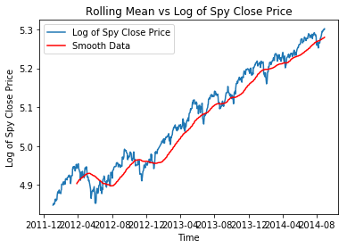

```python
moving_avg = pd.rolling_mean(ts_log,60)
o, =plt.plot(ts_log, label = "Log of Spy Close Price")
s, = plt.plot(moving_avg, color='red', label = "Smooth Data")
plt.title("Rolling Mean vs Log of Spy Close Price")
plt.ylabel("Log of Spy Close Price")
plt.xlabel("Time")
plt.legend(handles = [o,s])
plt.show()
plt.figure(figsize=(3,4))
```

## The rolling mean is now subtracted from the log of the data. The empty values are dropped. The difference between the rolling average and the log of the data is now tested for stationarity.

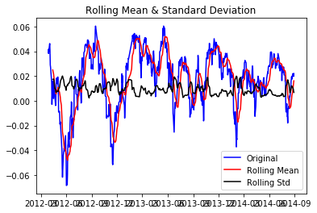

```
Results of Dickey-Fuller Test:
Test Statistic                  -4.018539
p-value                          0.001316
#Lags Used                       0.000000
Number of Observations Used    607.000000
Critical Value (1%)             -3.441169
Critical Value (5%)             -2.866313
Critical Value (10%)            -2.569312
dtype: float64
```

```python
ts_log_moving_avg_diff = ts_log - moving_avg
ts_log_moving_avg_diff.dropna(inplace=True)
test_stationarity(ts_log_moving_avg_diff)
```

### The test statistic is smaller than the critical value of 1%. So the difference between the log of the data and the rolling average is stationary with a 99% confidence level.

### The exponentially weighter average is graphed, and smoothed using every 60 values.

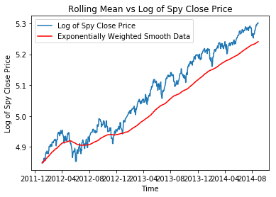

```python
expwighted_avg = pd.ewma(ts_log, halflife=60)
o, = plt.plot(ts_log, label = "Log of Spy Close Price")
s, =plt.plot(expwighted_avg, color='red', label = "Exponentially Weighted Smooth Data")

plt.title("Rolling Mean vs Log of Spy Close Price")
plt.ylabel("Log of Spy Close Price")
plt.xlabel("Time")
plt.legend(handles = [o,s])
```

### Once again, the difference between the log of the data and the smooth data is taken and tested for stationarity.

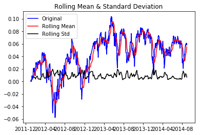

```
Results of Dickey-Fuller Test:
Test Statistic                  -3.388132
p-value                          0.011370
#Lags Used                       0.000000
Number of Observations Used    666.000000
Critical Value (1%)             -3.440207
Critical Value (5%)             -2.865889
Critical Value (10%)            -2.569086
dtype: float64
```

```python
ts_log_ewma_diff = ts_log - expwighted_avg
test_stationarity(ts_log_ewma_diff)
```

# Now trend and seasonality will be eliminated first using differencing then using decomposition.

```
Text(0.5,1,'Data after differencing')
```

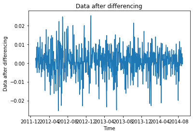

```python
ts_log_diff = ts_log - ts_log.shift()
plt.plot(ts_log_diff)
plt.ylabel("Data after differencing")
plt.xlabel("Time")
plt.title("Data after differencing")
```

## The data after differencing is then tested for stationarity.

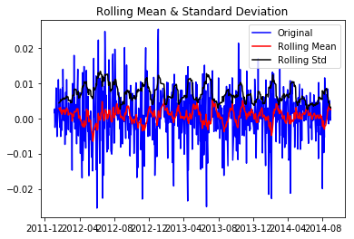

```
Results of Dickey-Fuller Test:
Test Statistic                -1.349035e+01
p-value                        3.115001e-25
#Lags Used                     4.000000e+00
Number of Observations Used    6.610000e+02
Critical Value (1%)           -3.440282e+00
Critical Value (5%)           -2.865922e+00
Critical Value (10%)          -2.569104e+00
dtype: float64
```

```python
ts_log_diff.dropna(inplace=True)
test_stationarity(ts_log_diff)
```

## Once again, the test statistic is much smaller than the critical value at 1%, so the data is stationary with a 99% confidence level. Now the trend and seasonality will be eliminated using decomposition, and test the data for stationarity.

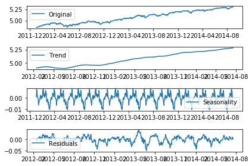

```python
from statsmodels.tsa.seasonal import seasonal_decompose
decomposition = seasonal_decompose(ts_log, freq=60)

trend = decomposition.trend
seasonal = decomposition.seasonal
residual = decomposition.resid
plt.title("Original, Trend, Seasonality, and Residual Log of data Time Series Graphs")
plt.subplot(411)
plt.plot(ts_log, label='Original')
plt.legend(loc='best')
plt.subplot(412)
plt.plot(trend, label='Trend')
plt.legend(loc='best')
plt.subplot(413)
plt.plot(seasonal,label='Seasonality')
plt.legend(loc='best')
plt.subplot(414)
plt.plot(residual, label='Residuals')
plt.legend(loc='best')
plt.tight_layout()
```

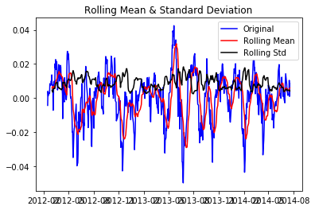

```
Results of Dickey-Fuller Test:
Test Statistic                -6.351741e+00
p-value                        2.600745e-08
#Lags Used                     1.000000e+01
Number of Observations Used    5.960000e+02
Critical Value (1%)           -3.441370e+00
Critical Value (5%)           -2.866402e+00
Critical Value (10%)          -2.569359e+00
dtype: float64
```

```python
ts_log_decompose = residual
ts_log_decompose.dropna(inplace=True)
test_stationarity(ts_log_decompose)
```

## Once again, the data is stationary because the test statistic is smaller than the critical value.

# Now, the spy close price will be forecasted using autoregressive integrated moving average.

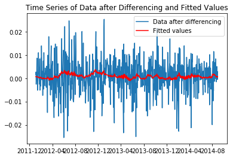

```
RSS: 0.0350
```

```python
#predicting using time series
from statsmodels.tsa.arima_model import ARIMA
#mixed model
model = ARIMA(ts_log, order=(2, 1, 2))
results_ARIMA = model.fit(disp=-1)
o, =plt.plot(ts_log_diff, label = "Data after differencing")
f, =plt.plot(results_ARIMA.fittedvalues, color='red', label = "Fitted values")
plt.legend(handles = [o,f])
plt.title("Time Series of Data after Differencing and Fitted Values")
plt.show()
print('RSS: %.4f'% sum((results_ARIMA.fittedvalues-ts_log_diff)**2))
```

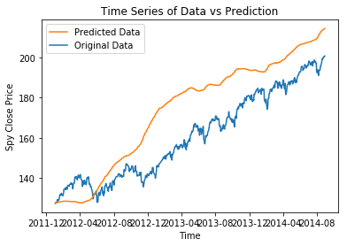

```
RMSE: 16.6270
```

```python
predictions_ARIMA_diff = pd.Series(results_ARIMA.fittedvalues, copy=True)

predictions_ARIMA_diff_cumsum = predictions_ARIMA_diff.cumsum()

predictions_ARIMA_log = pd.Series(ts_log.ix[0], index=ts_log.index)
predictions_ARIMA_log = predictions_ARIMA_log.add(predictions_ARIMA_diff_cumsum,fill_value=0)
predictions_ARIMA_log.head()


predictions_ARIMA = np.exp(predictions_ARIMA_log)
o, = plt.plot(ts, label = "Original Data")
a, = plt.plot(predictions_ARIMA, label = "Predicted Data")
plt.title("Time Series of Data vs Prediction")
plt.xlabel("Time")
plt.ylabel("Spy Close Price")
plt.legend(handles = [a,o])
plt.show()
print('RMSE: %.4f'% np.sqrt(sum((predictions_ARIMA-ts)**2)/len(ts)))
```